# Curso Estatística em R - UNICAMP - Avaliação

Samya de Lara Pinheiro

Esta é a avaliação da aluna Samya de Lara Pinheiro, submetida para o curso de extensão “Estatística para Geociências usando R”, ministrado no 1o semestre de 2021.

```r
print("Vamos lá!")
```

```
[1] "Vamos lá!"
```

# Questão 1

Use o conjunto de dados biogeoquímicos em (https://www.sciencebase.gov/catalog/item/5fec8c1ed34ea5387defd59d). Analise a normalidade de todos os dados numéricos, faça transformações quando necessário ou possível. Proponha um modelo usando os dados normais ou normalizados que tenha a concentração de sulfato como saída em função dos outros parâmetros.

## Resolução

*O url indicado não retorna nenhum banco de dados e deve estar `quebrado`. Assim irei utilizar o banco de dados já abordado em aula Earth Chem.* Inicialmente iremos carregar os dados e analisar a normalidade através de dois métodos:  
- análise dos histogramas  
- teste de Shapiro-Wilk

```r
#### CARREGANDO DADOS
library(xlsx)
arq <- "/Users/samyadelara/Desktop/DataScience/Cursos avulsos/CursoR_UNICAMP/dadosEarthChem.xlsx"
data <- read.xlsx(arq,startRow = 4, sheetName = 'Sheet1', header = FALSE)
nomes <- read.xlsx(arq,startRow = 2, endRow = 3, sheetName <- 'Sheet1', header = FALSE)
colnames(data) <- nomes[1,]
data <- data[,-8]
head(data)
```

|  | Sample Name | IGSN | Latitude | Longitude | Depth | H2O | Cl | SiO2 | TiO2 | Al2O3 | FeOT | MnO | MgO | CaO | Na2O | K2O | P2O5 |
| --- | --- | --- | --- | --- | --- | --- | --- | --- | --- | --- | --- | --- | --- | --- | --- | --- | --- |
| 1 | EN061 01D-1g | URI900742 | -1.407 | -13.175 | 2600 | 0.168 | 93 | 51.08 | 1.21 | 16.09 | 8.61 | 0.18 | 8.58 | 11.51 | 2.87 | 0.11 | 0.27 |
| 2 | EN061 02D-1g | URI900744 | -2.238 | -12.397 | 3885 | 0.119 | 39 | 50.34 | 1.21 | 16.13 | 8.93 | 0.18 | 9.01 | 11.74 | 2.40 | 0.04 | 0.36 |
| 3 | EN061 03D-1g | URI900746 | -3.433 | -12.225 | 3045 | 0.111 | 1 | 51.04 | 1.19 | 15.66 | 8.81 | 0.18 | 8.76 | 11.90 | 2.43 | 0.06 | 0.27 |
| 4 | EN061 04D-1g | URI900747 | -4.272 | -12.198 | 2300 | 0.158 | 65 | 50.97 | 1.46 | 15.13 | 9.80 | 0.21 | 8.11 | 11.48 | 2.66 | 0.08 | 0.30 |
| 5 | EN061 05D-1Ag | URI900748 | -5.185 | -11.517 | 3300 | 0.222 | 76 | 51.08 | 1.34 | 14.67 | 10.36 | 0.21 | 8.40 | 11.12 | 2.37 | 0.12 | 0.32 |
| 6 | EN061 05D-3A | URI900749 | -5.185 | -11.517 | 3300 | 0.127 | NA | NA | NA | NA | NA | NA | NA | NA | NA | NA | NA |

```r
str(data)
```

```
'data.frame':   144 obs. of  17 variables:
 $ Sample Name: chr  "EN061 01D-1g" "EN061 02D-1g" "EN061 03D-1g" "EN061 04D-1g" ...
 $ IGSN       : chr  "URI900742" "URI900744" "URI900746" "URI900747" ...
 $ Latitude   : num  -1.41 -2.24 -3.43 -4.27 -5.18 ...
 $ Longitude  : num  -13.2 -12.4 -12.2 -12.2 -11.5 ...
 $ Depth      : num  2600 3885 3045 2300 3300 ...
 $ H2O        : num  0.168 0.119 0.111 0.158 0.222 0.127 0.168 NA 0.075 NA ...
 $ Cl         : num  93 39 1 65 76 NA 87 68 86 28 ...
 $ SiO2       : num  51.1 50.3 51 51 51.1 ...
 $ TiO2       : num  1.21 1.21 1.19 1.46 1.34 NA 1.09 NA 1.14 1.13 ...
 $ Al2O3      : num  16.1 16.1 15.7 15.1 14.7 ...
 $ FeOT       : num  8.61 8.93 8.81 9.8 10.36 ...
 $ MnO        : num  0.18 0.18 0.18 0.21 0.21 NA 0.19 NA 0.16 0.17 ...
 $ MgO        : num  8.58 9.01 8.76 8.11 8.4 NA 8.94 NA 8.69 8.75 ...
 $ CaO        : num  11.5 11.7 11.9 11.5 11.1 ...
 $ Na2O       : num  2.87 2.4 2.43 2.66 2.37 NA 2.54 NA 2.36 2.29 ...
 $ K2O        : num  0.11 0.04 0.06 0.08 0.12 NA 0.1 NA 0.04 0.03 ...
 $ P2O5       : num  0.27 0.36 0.27 0.3 0.32 NA 0.27 NA 0.071 0.086 ...
```

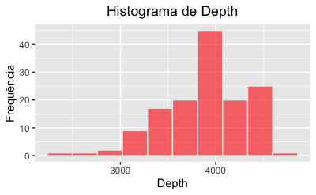

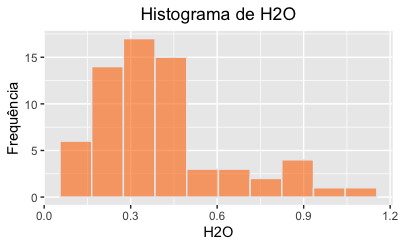

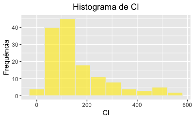

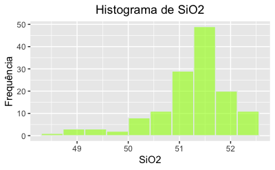

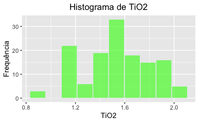

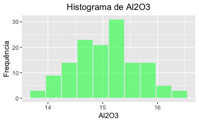

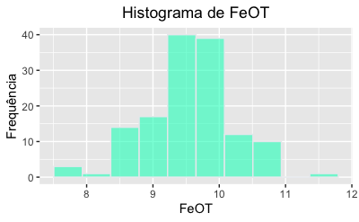

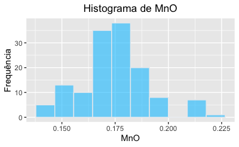

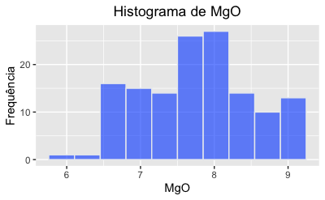

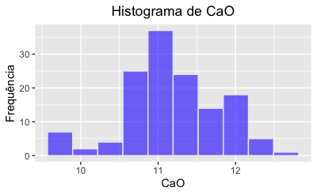

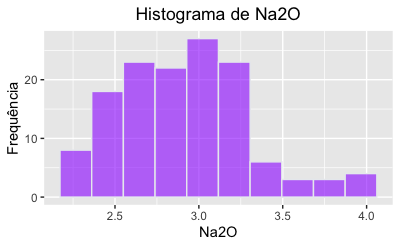

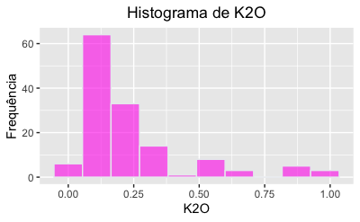

[1 more figures not shown]

```r
#### HISTOGRAMA DAS VARIÁVEIS
library(ggplot2)
cores <- rainbow(13)
for(i in 5:17) {
  g <- ggplot(data=data, aes(data[,i])) +
  geom_histogram(color = "#e9ecef", fill = cores[i-4], alpha = 0.6, position = "identity", bins = 10) +
  labs(title = paste0("Histograma de ", colnames(data)[i]),x=colnames(data)[i], y="Frequência") +
  theme(plot.title = element_text(hjust = 0.5))
  print(g)
}
```

```r
####  TESTE DE SHAPIRO DAS VARIÁVEIS
d <- data[,5:17]
pval = data.frame(matrix(NA,dim(d)[2],1))
rownames(pval) = colnames(d)
colnames(pval) = c("pvalue")
for (i in 1:13) {
  pval[i,1] = shapiro.test(d[,i])$p.value
}
pval
```

|  | pvalue |
| --- | --- |
| Depth | 3.570834e-04 |
| H2O | 4.633472e-05 |
| Cl | 7.908156e-11 |
| SiO2 | 2.694926e-08 |
| TiO2 | 8.946288e-03 |
| Al2O3 | 4.510552e-01 |
| FeOT | 3.007608e-02 |
| MnO | 2.028559e-04 |
| MgO | 2.918131e-02 |
| CaO | 3.123233e-03 |

[output cut: 3 more lines]

```r
NA
```

Apenas a variável `Al2O3` pode ser considerada normal, à medida que seu histograma se aproxima de uma Gaussiana e no teste de Shapiro a hipótese nula não foi rejeitada, i.e. distribuição da variável é comparável à distr. normal.  
Para as outras variáveis as distribuições parecem mais assimétricas (`FeO` e `MnO` possuem um histograma bem sugestivo de distribuição normal, contudo pelo teste de Shapiro, a normalidade não foi confirmada). Para trabalhar com estas variáveis em modelos de regressão iremos aplicar transformações.

Utilizando a função de `Box-Cox`, iremos descobrir a potência $\lambda$ que deve ser aplicada como potência na variável para normalizá-la.

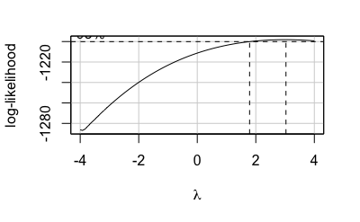

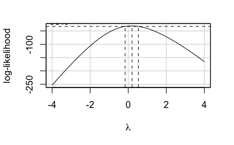

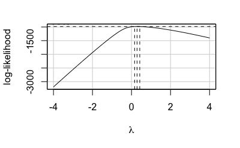

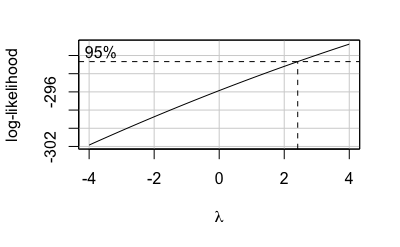

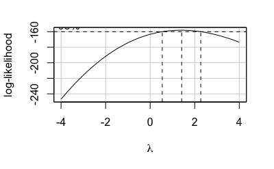

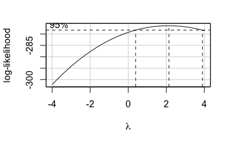

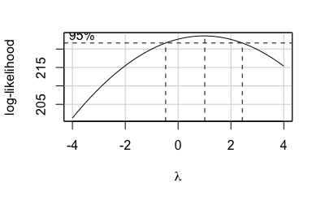

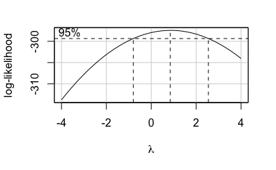

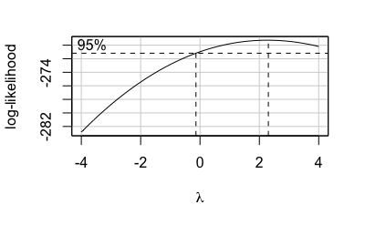

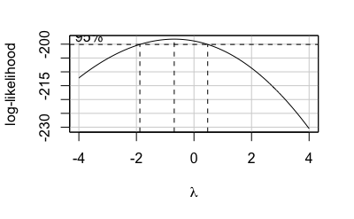

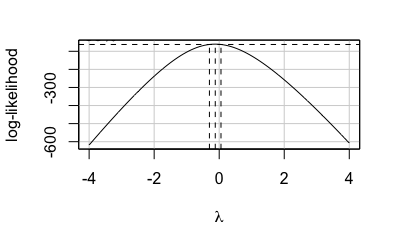

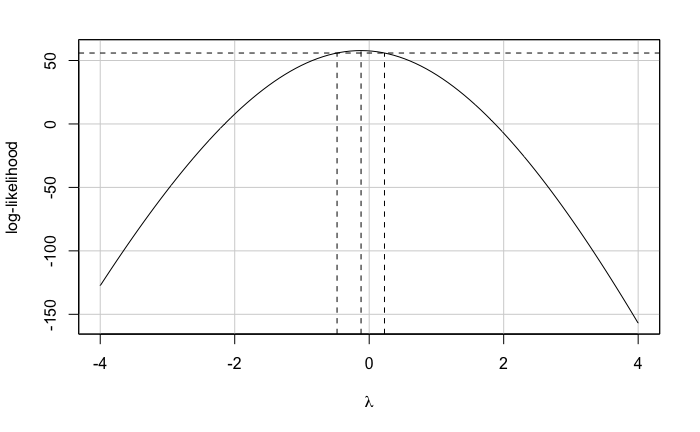

```r
library(car)

####  CÁLCULO DE LAMBDAS
lamb <- data.frame(matrix(NA,12,1))
rownames(lamb) <- colnames(d)[-6]
colnames(lamb) <- c("lambdaBC")
var2norm <- c(1:5,7:13)
j <- 14
for (i in var2norm) {
  nom <- colnames(d)[i]
  colnames(d)[i] <- "Y"
  res <- boxCox(d$Y ~ 1, data = d[,i],  lambda = seq(-4,4,length=50))
  im <- which.max(res$y)
  lam <- res$x[im]
  tmp <- bcPower(d[,i], lam)
  lamb[j-13,1] <- lam
  d[,j] <- tmp
  colnames(d)[i] <- nom
  colnames(d)[j] <- paste0("t_",nom)
  j <- j+1

}
```

```r
lamb
```

|  | lambdaBC |
| --- | --- |
| Depth | 3.0303030 |
| H2O | 0.2020202 |
| Cl | 0.2828283 |
| SiO2 | 4.0000000 |
| TiO2 | 1.4141414 |
| FeOT | 2.1414141 |
| MnO | 1.0101010 |
| MgO | 0.8484848 |
| CaO | 2.3030303 |
| Na2O | -0.6868687 |

[output cut: 2 more lines]

```r
head(d)
```

|  | Depth | H2O | Cl | SiO2 | TiO2 | Al2O3 | FeOT | MnO | MgO | CaO | Na2O | K2O | P2O5 | t_Depth | t_H2O | t_Cl | t_SiO2 | t_TiO2 | t_FeOT | t_MnO | t_MgO | t_CaO | t_Na2O | t_K2O | t_P2O5 |
| --- | --- | --- | --- | --- | --- | --- | --- | --- | --- | --- | --- | --- | --- | --- | --- | --- | --- | --- | --- | --- | --- | --- | --- | --- | --- |
| 1 | 2600 | 0.168 | 93 | 51.08 | 1.21 | 16.09 | 8.61 | 0.18 | 8.58 | 11.51 | 2.87 | 0.11 | 0.27 | 7360681476 | -1.497752 | 9.205764 | 1701937 | 0.2187855 | 46.47142 | -0.8148601 | 6.122822 | 120.1774 | 0.7501800 | -2.530745 | -1.418955 |
| 2 | 3885 | 0.119 | 39 | 50.34 | 1.21 | 16.13 | 8.93 | 0.18 | 9.01 | 11.74 | 2.40 | 0.04 | 0.36 | 24857441970 | -1.730066 | 6.429238 | 1605435 | 0.2187855 | 50.28653 | -0.8148601 | 6.432143 | 125.8004 | 0.6579408 | -3.937124 | -1.087604 |
| 3 | 3045 | 0.111 | 1 | 51.04 | 1.19 | 15.66 | 8.81 | 0.18 | 8.76 | 11.90 | 2.43 | 0.06 | 0.27 | 11880619369 | -1.775019 | 0.000000 | 1696612 | 0.1972169 | 48.83724 | -0.8148601 | 6.252584 | 129.7978 | 0.6647204 | -3.352640 | -1.418955 |
| 4 | 2300 | 0.158 | 65 | 50.97 | 1.46 | 15.13 | 9.80 | 0.21 | 8.11 | 11.48 | 2.66 | 0.08 | 0.30 | 5076542056 | -1.540288 | 7.978130 | 1687324 | 0.5004634 | 61.46641 | -0.7853517 | 5.782023 | 119.4546 | 0.7123697 | -2.955023 | -1.296259 |
| 5 | 3300 | 0.222 | 76 | 51.08 | 1.34 | 14.67 | 10.36 | 0.21 | 8.40 | 11.12 | 2.37 | 0.12 | 0.32 | 15159238789 | -1.297794 | 8.498686 | 1701937 | 0.3625308 | 69.29279 | -0.7853517 | 5.992646 | 110.9725 | 0.6510167 | -2.417640 | -1.221871 |
| 6 | 3300 | 0.127 | NA | NA | NA | NA | NA | NA | NA | NA | NA | NA | NA | 15159238789 | -1.687463 | NA | NA | NA | NA | NA | NA | NA | NA | NA | NA |

```r
NA
```

```r
pval <- data.frame(matrix(NA,dim(d)[2],1))
rownames(pval) <- colnames(d)
colnames(pval) <- c("pvalue")
for (i in 1:dim(d)[2]) {
  pval[i,1] <- shapiro.test(d[,i])$p.value
}
pval
```

|  | pvalue |
| --- | --- |
| Depth | 3.570834e-04 |
| H2O | 4.633472e-05 |
| Cl | 7.908156e-11 |
| SiO2 | 2.694926e-08 |
| TiO2 | 8.946288e-03 |
| Al2O3 | 4.510552e-01 |
| FeOT | 3.007608e-02 |
| MnO | 2.028559e-04 |
| MgO | 2.918131e-02 |
| CaO | 3.123233e-03 |

[output cut: 15 more lines]

Finalmente podemos fazer um modelo de regressão relacionando a profundidade com os outros parâmetros. Testaremos as correlações para uma avaliação preliminar das variáveis e em seguida, utilizar a função `lm` para definir o modelo e analisar coeficientes e significância.

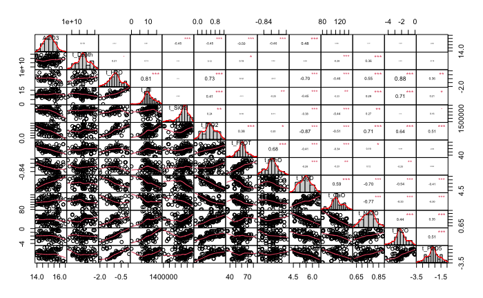

Correlações interessantes com `CaO` e `Na2O`.

```r
modelo = mod2
summary(modelo)
```

[output not shown]

```
Call:
lm(formula = Depth ~ t_Na2O, data = d)

Residuals:
     Min       1Q   Median       3Q      Max
-1485.04  -139.36    39.04   250.78   818.36

Coefficients:
            Estimate Std. Error t value Pr(>|t|)
(Intercept)   2026.6      433.5   4.675 7.04e-06
t_Na2O        2468.5      575.1   4.292 3.35e-05

(Intercept) ***
t_Na2O      ***
---
Signif. codes:
0 ‘***’ 0.001 ‘**’ 0.01 ‘*’ 0.05 ‘.’ 0.1 ‘ ’ 1

Residual standard error: 407.3 on 135 degrees of freedom
  (7 observations deleted due to missingness)
Multiple R-squared:  0.1201,    Adjusted R-squared:  0.1136
F-statistic: 18.42 on 1 and 135 DF,  p-value: 3.351e-05
```

Após alguns testes, estabelecemos um modelo linear para a profundidade a partir dos dados de `Na2O`.

# Questão 2

Pesquise em bases de dados públicas informações para construir um classificador de áreas em risco de contaminação ou contaminadas em bacias hidrográficas. Seja criativo e procure por informações que tenham relevância, proximidade de grandes centros, fluxo, vazão, pluviometria, entre outros. Sugere-se usar dados de um mesmo país ou região. Tente aplicar alguma técnica de aprendizado de máquina.

## Resolução

Não consegui estabelecer uma base de dados a tempo de enviar a avaliação.

# Questão 3

Uma pequena digressão fora das geociências. Use os dados de propriedades de vinhos de diversas marcas que podem ser encontrados em (https://archive.ics.uci.edu/ml/datasets/wine). Tente estabelecer se é possível agrupar esses vinhos de alguma forma com essas propriedades.

## Resolução

Inicialmente iremos baixar os dados e analisar a normalidade através da análise dos histogramas e correlações

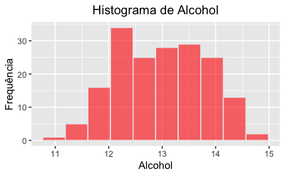

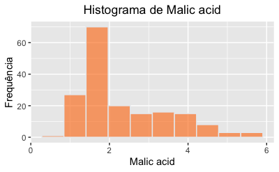

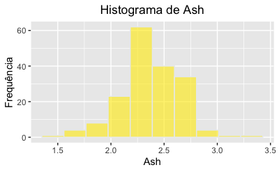

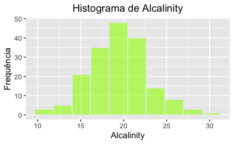

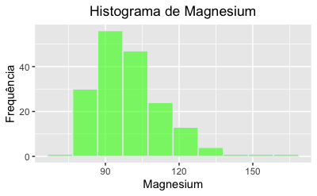

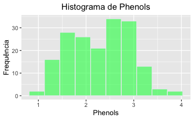

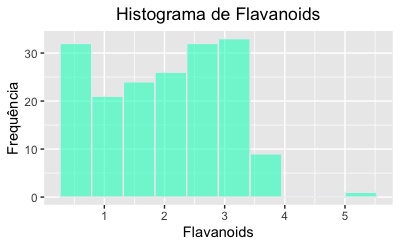

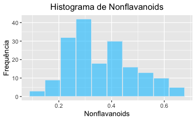

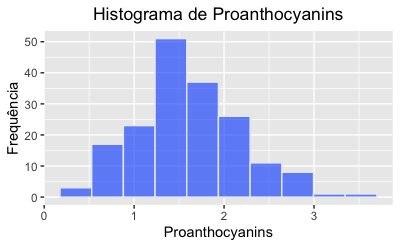

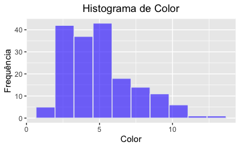

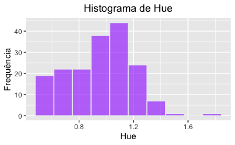

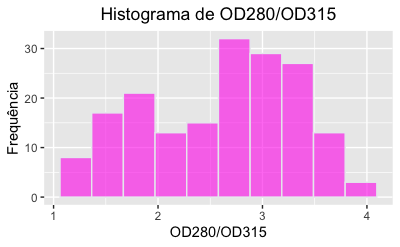

[1 more figures not shown]

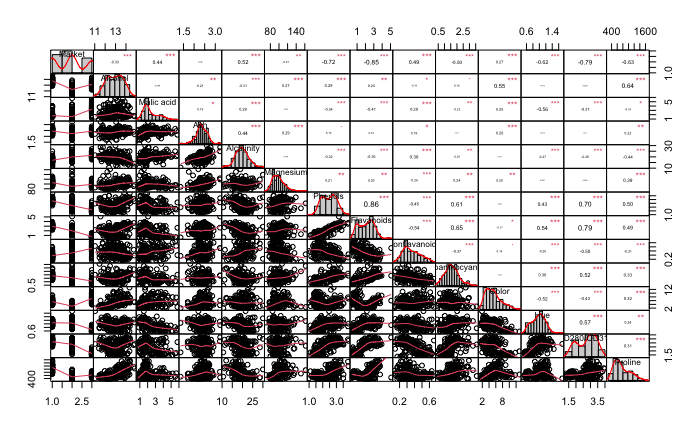

```r
#### CORRELAÇÕES
library(PerformanceAnalytics)
chart.Correlation(data, histogram = T)
```

Para agrupar as variáveis antes de agrupar os vinhos, será utilizada uma técnica de análise de fatores através de **PCA**. Após o agrupamento e identificação dos fatores será aplicada um agrupamentos dos registros com base no algoritmo de k-means.

```r
pca_r = prcomp(data)
pca_r
```

```
Standard deviations (1, .., p=14):
 [1] 314.96353873  13.13531864   3.08726351
 [4]   2.25849728   1.13392604   0.93175457
 [7]   0.53573032   0.39405452   0.33724371
[10]   0.29390207   0.21494794   0.18688848
[13]   0.14409259   0.08995921

Rotation (n x k) = (14 x 14):
                          PC1           PC2
Market           0.0015593428 -2.778618e-03
Alcohol         -0.0016592619 -1.204267e-03
Malic acid       0.0006810190 -2.159531e-03
Ash             -0.0001949052 -4.593996e-03
Alcalinity       0.0046713046 -2.646070e-02
Magnesium       -0.0178679787 -9.993399e-01
Phenols         -0.0009898316 -8.747309e-04
Flavanoids      -0.0015672929  5.865826e-05
Nonflavanoids    0.0001230870  1.353994e-03
Proanthocyanins -0.0006006091 -5.002227e-03
Color           -0.0023271272 -1.511422e-02
Hue             -0.0001713811  7.640425e-04
OD280/OD315     -0.0007049359  3.500684e-03
Proline         -0.9998217211  1.776936e-02
                        PC3          PC4
Market          -0.10091996 -0.147645845
Alcohol         -0.01830354 -0.136988601
Malic acid      -0.12455946 -0.156739376
Ash             -0.05129289  0.012047122
Alcalinity      -0.92809986  0.356990103
Magnesium        0.02998454  0.004754117
Phenols          0.04276110  0.076452064
Flavanoids       0.09026712  0.172191025
Nonflavanoids   -0.01372151 -0.010593546
Proanthocyanins  0.02623713  0.051606406
Color           -0.30320298 -0.856516199
Hue              0.02699227  0.059055310
OD280/OD315      0.07436620  0.178526137
Proline         -0.00462656  0.002950572
                         PC5          PC6
Market           0.219197410  0.168685378
```

[output cut: 58 more lines]

```
                         PC13          PC14
Market           9.598765e-02 -4.715808e-02
Alcohol         -4.240326e-03 -1.342199e-02
Malic acid       6.323570e-02  1.205487e-02
Ash             -8.648809e-02  1.623446e-01
Alcalinity       2.694858e-04  6.483270e-05
Magnesium        5.009661e-04 -2.271269e-03
Phenols         -1.908158e-02  3.464768e-02
Flavanoids      -1.971202e-04 -8.667150e-02
Nonflavanoids    1.329541e-01 -9.672182e-01
Proanthocyanins -1.502505e-02  1.929259e-02
Color            4.256684e-02  7.836890e-03
Hue              9.786547e-01  1.523550e-01
OD280/OD315      3.801870e-02 -5.675071e-02
Proline         -4.006096e-05 -6.726096e-05
```

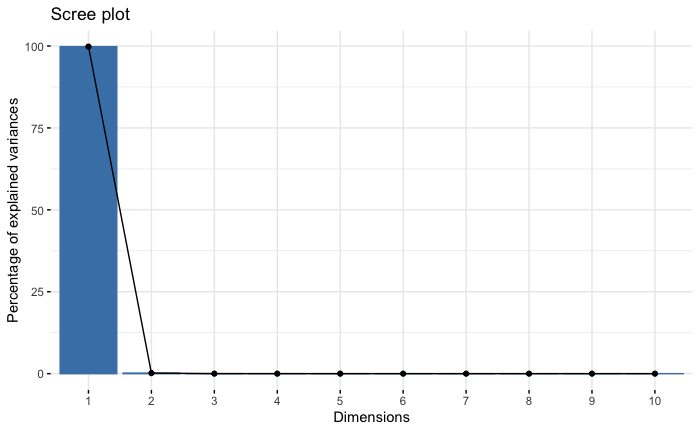

```r
library(factoextra)
fviz_eig(pca_r)
```

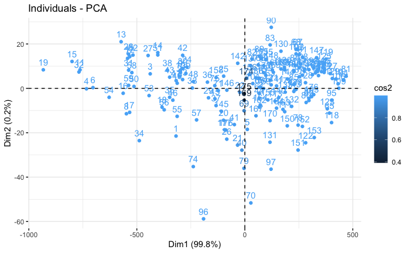

```r
fviz_pca_ind(pca_r, col.ind = 'cos2')
```

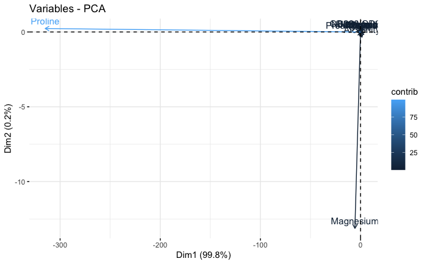

```r
fviz_pca_var(pca_r, col.var = 'contrib')
```

[figure not shown]

Finalmente avaliamos valores médios das variáveias em cada grupo.

```r
data$cluster <- kpca$cluster
aggregate(data,by=list(data$cluster), mean)
```

| Group.1 | Market | Alcohol | Malic acid | Ash | Alcalinity | Magnesium | Phenols | Flavanoids | Nonflavanoids | Proanthocyanins | Color | Hue | OD280/OD315 | Proline | cluster |
| --- | --- | --- | --- | --- | --- | --- | --- | --- | --- | --- | --- | --- | --- | --- | --- |
| 1 | 2.423729 | 12.87000 | 2.697627 | 2.379322 | 20.24068 | 99.83051 | 2.027627 | 1.427288 | 0.4042373 | 1.434915 | 5.551525 | 0.8705085 | 2.270169 | 659.2203 | 1 |
| 2 | 1.000000 | 13.86000 | 1.793913 | 2.506957 | 17.07391 | 106.00000 | 2.943043 | 3.110870 | 0.2986957 | 1.926087 | 6.260000 | 1.1000000 | 3.035652 | 1338.5652 | 2 |
| 3 | 1.358974 | 13.45949 | 2.125897 | 2.390769 | 18.12564 | 107.64103 | 2.594359 | 2.532821 | 0.3035897 | 1.808205 | 5.219231 | 1.0004103 | 2.976667 | 985.5897 | 3 |
| 4 | 2.210526 | 12.47509 | 2.325263 | 2.280000 | 20.63684 | 91.71930 | 2.105789 | 1.871404 | 0.3833333 | 1.468421 | 3.952105 | 0.9605263 | 2.544386 | 435.5789 | 4 |

# Questão 4

Descreva em texto como você lida com um conjunto de dados que precisa analisar. Quais as principais etapas?

## Resolução

Em uma análise de dados, inicialmente importo os dados no RStudio (ou Python-Colab/Jupyter). Em geral, essa já é uma atividade que demanda bastante tempo já que os dados podem possuir uma estrutura bem diferente, formato, cabeçalhos, etc. Após importar passo para uma análise exploratória:  
- caracterização dos tipos de variáveis

- análise das estatísticas descritivas gerais (médias, desvio padrão, mediana)
- quantidade de NA`s
- caracterização de distribuições com análise de histogramas e boxplots

De acordo com essa análise exploratória, reflito sobre que tipos de análises posso aplicar aos dados, técnicas de agrupamento, regressão, tabelas de contingência, anova, etc conforme o fenômeno que quero estudar e hipóteses que quero confirmar. Nesta reflexão também avalio a necessidade de tratamento de `missing values` (exclusão, ou preenchimento) ou de normalizar as variáveis (caso para alguma das análises esse seja um dos pressupostos).  
De acordo com essa escolha de análise o fluxo de tratamento dos dados pode incluir seleção de amostra treino e teste, ou criação de gráficos para evidenciar achados como agrupamentos ou relações entre variáveis.